# Session 6 - The Layered Grammar of Graphics

# Ein “schöner” Plot (3 Layer) II

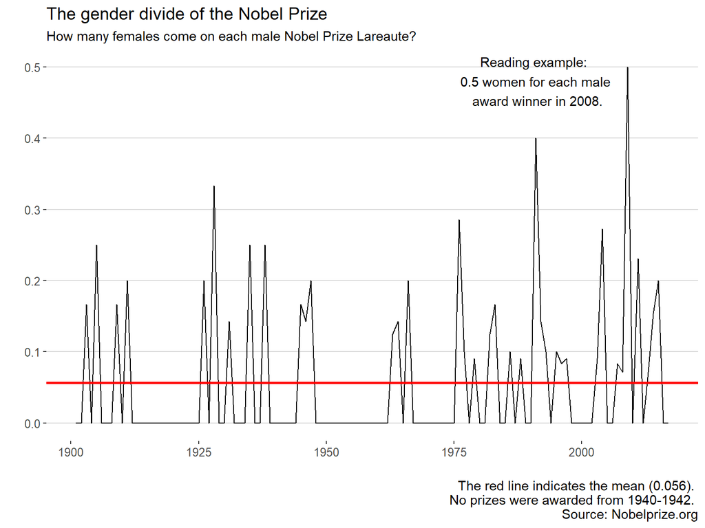

# Ein “schöner” Plot (3 Layer) III

[figure not shown]

```r
finplot
```

# Warum visualisieren?

> On January 28, 1986, the space shuttle Challenger exploded and seven austronauts died because two rubber O-rings leaked. These rings had lost their resiliency because the shuttle was launched on a very cold day (Tufte 1997: 39).

[figure not shown]

# Space Shuttle Challenger I

Am Tag vor dem Start von Space Shuttle Challenger wurden 13 Folien erstellt, welche die NASA-Manager vom Start der Rakete abhalten sollten.

> “The charts were unconvincing” (Tufte 1997: 30):
1. Die Folien enthielten keine Namen.
- Glaubwürdigkeit
- Zurechenbarkeit
2. Die Tabellen enthielten den Effekt (Dichtungsringschaden) aber nicht zusammen mit der Ursache.
3. Zu viel unnötige Information.
4. Es fehlten Fälle, die den Kontext darstellen.

# Space Shuttle Challenger II

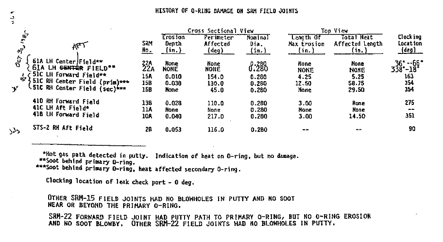

# Space Shuttle Challenger III

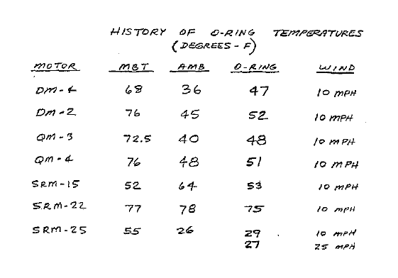

# Tuftes Visualisierung

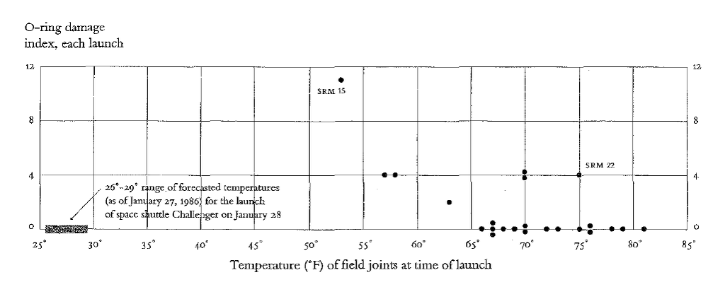

# Warum visualisieren?

> “Numbers become evidence by being in relation to” (Tufte 1997: 44)
1. Grafiken setzen Daten ins Verhältnis zueinander.
2. Menschen können besser räumliche Objekte in Beziehung setzen als Zahlen in Tabellen.

# Grafik reproduzieren I

Die Daten sind auf Moodle verfügbar (`readRDS`) und bereits von Fahrenheit in Celsius umgerechnet.

Versucht die Grafik von Tufte zu reproduzieren.

# Grafik reproduzieren II

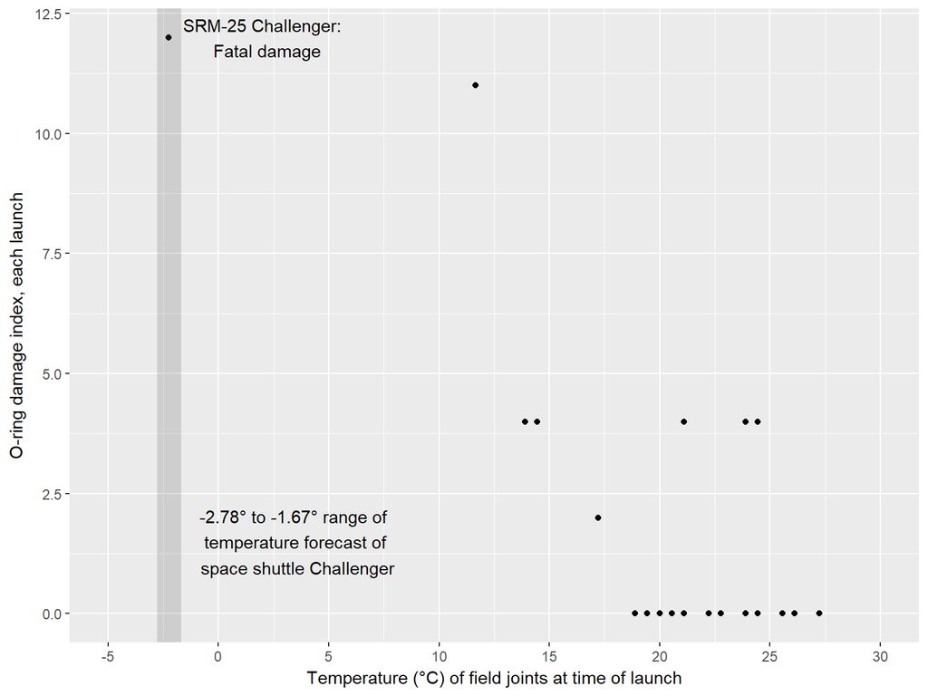

# Aufgabe: Data-ink ratio

Tufte (1997: 92-105) schlägt vor, dass Grafiken sich unter anderem anhand ihrer “data-ink ratio” beurteilen lassen. Die “data ink-ratio” bestimmt das Verhältnis zwischen “Farbe”, die Daten darstellt und derjenigen, welche ersetzt werden kann ohne das es zu einem Informationsverlust kommt:

Data-ink ration = data-ink / total ink used to print the graphic

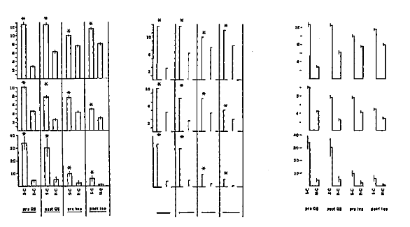

# Ein Beispiel

Vieles lässt sich über [`theme`](http://ggplot2.tidyverse.org/reference/theme.html) steuern.

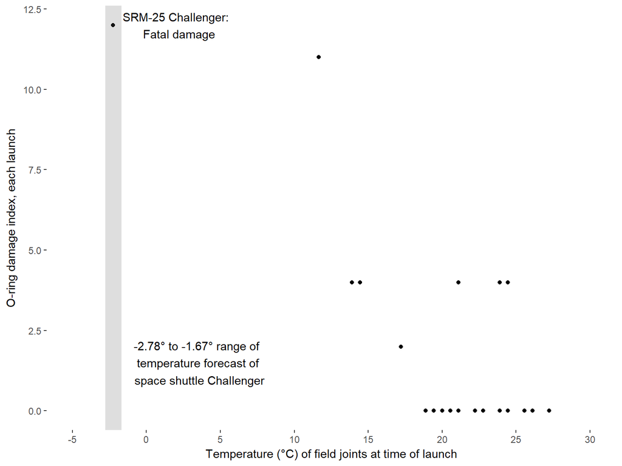

```r
space.plot +
  theme(panel.background = element_rect(fill = "white"))
```